# Tugas Pertemuan 4

# White Noise

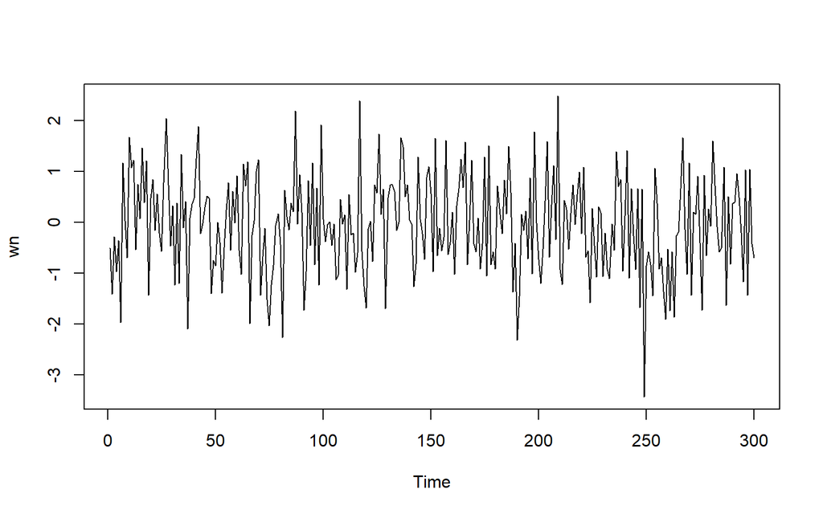

```r
set.seed(1026)
wn <- rnorm(300)
ts.plot(wn)
```

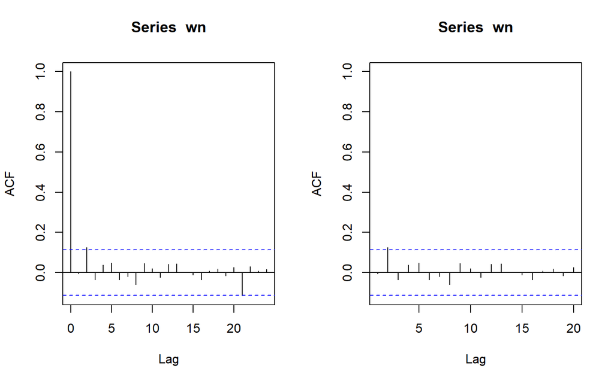

```r
par(mfrow = c(1, 2))
acf(wn)
acf(wn, xlim = c(1, 20))
```

# Model MA(2)

Akan dibangkitkan secara manual sebanyak 300 data dengan model MA(2) yang memiliki nilai $\theta_1 = 0.4$ dan $\theta_2 = 0.6$.

$$y_t = e_t-0.4e_{t-1}-0.6e_{t-2}$$

```r
set.seed(1026)
ma <- c(1:300)
ma[1] <- wn[1]
ma[2] <- ma[2] - 0.4 * ma[1]
```

```r
for(i in 3:300){
   ma[i] <- wn[i] - 0.4 * wn[i - 1] - 0.6 * wn[i - 2]
}
ma
```

```
##   [1] -0.511675097  2.204670039  0.589439802 -0.003805205  0.192585563
##   [6] -1.246277987  2.177726120  0.746196970 -1.407377246  1.927853926
##  [11]  0.821811712 -0.209096611 -1.669597098  0.223940757  0.091606999
##  [16]  0.991868139 -0.242080399  0.177135651 -2.153530986  0.323799884
##  [21]  1.518703978 -0.787047283  0.114631796 -0.337906117 -0.817485677
##  [26]  1.137010273  2.076258194 -0.553056849 -1.989941189  0.073907119
##  [31] -1.081906579  0.670795571 -0.611200381  1.595782007  0.074934998
##  [36] -0.353205886 -2.194623816  0.674758359  1.585470846  0.278618203
##  [41]  0.849269573  1.101426476 -1.733282151 -1.064294911  0.441748508
##  [46]  0.409717666  0.092625951 -1.904204710 -0.467787973  0.290330141
##  [51]  0.790376191  0.113542902 -1.236442612  0.298595735  1.277723127
##  [56]  0.983754445 -1.006947643  0.363419048  0.074350380  0.549655948
##  [61] -0.908778737 -1.353962623  1.881542057  0.875372173  0.219616306
##  [66] -2.900902898 -0.169420016  1.330991009  1.136354195  0.806932731
##  [71] -2.523990878 -0.835794093  1.008395032 -1.071124439 -1.354284687
```

[output cut: 45 more lines]

Pembangkitan model MA(2) juga dapat dilakukan dengan menerapkan fungsi `arima.sim()`

```r
ma2 <- arima.sim(list(order=c(0,0,2), ma=c(0.4, 0.6)), n=300)
ma2
```

```
## Time Series:
## Start = 1
## End = 300
## Frequency = 1
##   [1] -1.15675211 -1.92900282 -0.92092503 -2.69729859  0.16329181 -0.68354180
##   [7]  0.02229558  1.41141436  1.32647003  2.65377706  0.59724412  1.26180783
##  [13]  0.04249465  1.93695795  1.00991103  2.24156356 -0.72535292  0.62346585
##  [19]  0.17027992  0.45690572  0.99596551 -0.09175214 -0.32299059  0.42302481
##  [25]  2.01598647  2.01986207  1.05212769  0.57886485 -1.38348589  0.07630177
##  [31] -1.79159693  1.08292149 -0.29526199  1.16588541 -2.00174820 -0.51618273
##  [37] -0.86892211  0.66038307  1.65479932  2.66645480  1.27631170  1.01364567
##  [43]  0.14730654  0.61495014  0.85592610 -0.90998320 -1.02433191 -1.99503056
##  [49] -0.78677590 -0.90783723 -1.55200017 -1.29335798 -0.79324744  0.58068737
##  [55] -0.09048550  0.86311088 -0.09349754  1.27791504 -0.18923863 -0.69662698
##  [61]  0.40249579  0.55863355  2.16364131 -1.08719642 -0.33470518 -1.26351866
```

[output cut: 39 more lines]

## Plot Time Series

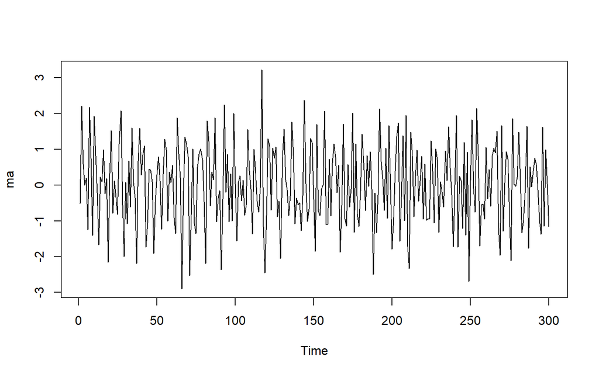

```r
ts.plot(ma)
```

Berdasarkan plot time series, dapat dilihat bahwa data dari model MA(2) yang dibangkitkan adalah stasioner dalam rataan.

## Plot ACF

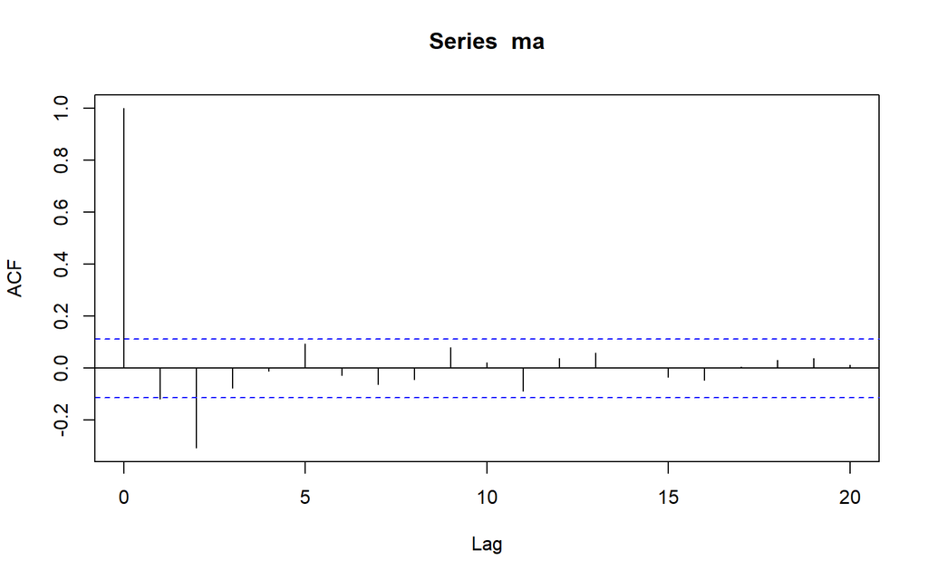

```r
acf(ma,lag.max = 20)
```

Berdasarkan plot AFC tersebut, dapat dilihat bahwa plot ACF *cuts off* di lag kedua.

## Plot PACF

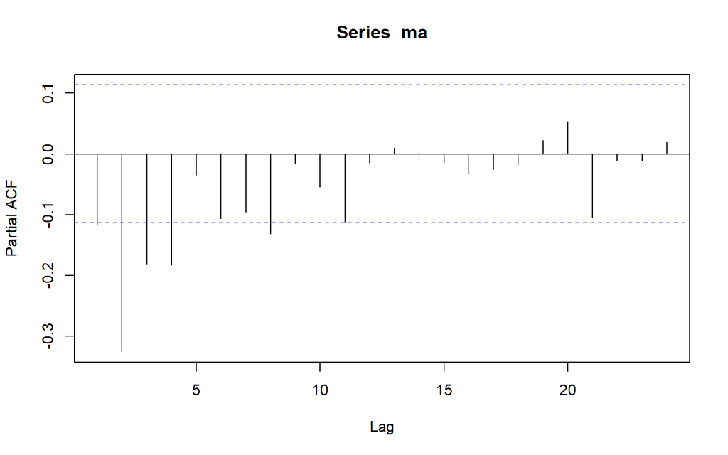

```r
pacf(ma)
```

Berdasarkan plot PACF, dapat dilihat bahwa plot PACF cenderung *tails off* dan membentuk gelombang lembah karena nilai teta adalah positif.

## Plot EACF

```r
TSA::eacf(ma)
```

```
## AR/MA
##   0 1 2 3 4 5 6 7 8 9 10 11 12 13
## 0 x x o o o o o o o o o  o  o  o
## 1 x x o o o o o o o o o  o  o  o
## 2 x x o x o o o o o o o  o  o  o
## 3 x x o x o o o o o o o  o  o  o
## 4 x x x x o o o o o o o  o  o  o
## 5 x x o x x o o o o o o  o  o  o
## 6 x x o x x x o x o o o  o  o  o
## 7 x x x x x x o x o o o  o  o  o
```

Berdasarkan pola segitiga nol pada plot EACF, dapat dilihat bahwa segitiga nol pertama terletak pada ordo AR(0) dan ordo MA(2).

## Scatterplot Antar Lag

### Korelasi antara $Y_t$ dengan $Y_{t-1}$

```r
yt_ma <- ma[-1]
yt_ma
```

```
##   [1]  2.204670039  0.589439802 -0.003805205  0.192585563 -1.246277987
##   [6]  2.177726120  0.746196970 -1.407377246  1.927853926  0.821811712
##  [11] -0.209096611 -1.669597098  0.223940757  0.091606999  0.991868139
##  [16] -0.242080399  0.177135651 -2.153530986  0.323799884  1.518703978
##  [21] -0.787047283  0.114631796 -0.337906117 -0.817485677  1.137010273
##  [26]  2.076258194 -0.553056849 -1.989941189  0.073907119 -1.081906579
##  [31]  0.670795571 -0.611200381  1.595782007  0.074934998 -0.353205886
##  [36] -2.194623816  0.674758359  1.585470846  0.278618203  0.849269573
##  [41]  1.101426476 -1.733282151 -1.064294911  0.441748508  0.409717666
##  [46]  0.092625951 -1.904204710 -0.467787973  0.290330141  0.790376191
##  [51]  0.113542902 -1.236442612  0.298595735  1.277723127  0.983754445
##  [56] -1.006947643  0.363419048  0.074350380  0.549655948 -0.908778737
##  [61] -1.353962623  1.881542057  0.875372173  0.219616306 -2.900902898
##  [66] -0.169420016  1.330991009  1.136354195  0.806932731 -2.523990878
##  [71] -0.835794093  1.008395032 -1.071124439 -1.354284687  0.493245076
```

[output cut: 45 more lines]

```r
yt_1_ma <- ma[-300]
yt_1_ma
```

```
##   [1] -0.511675097  2.204670039  0.589439802 -0.003805205  0.192585563
##   [6] -1.246277987  2.177726120  0.746196970 -1.407377246  1.927853926
##  [11]  0.821811712 -0.209096611 -1.669597098  0.223940757  0.091606999
##  [16]  0.991868139 -0.242080399  0.177135651 -2.153530986  0.323799884
##  [21]  1.518703978 -0.787047283  0.114631796 -0.337906117 -0.817485677
##  [26]  1.137010273  2.076258194 -0.553056849 -1.989941189  0.073907119
##  [31] -1.081906579  0.670795571 -0.611200381  1.595782007  0.074934998
##  [36] -0.353205886 -2.194623816  0.674758359  1.585470846  0.278618203
##  [41]  0.849269573  1.101426476 -1.733282151 -1.064294911  0.441748508
##  [46]  0.409717666  0.092625951 -1.904204710 -0.467787973  0.290330141
##  [51]  0.790376191  0.113542902 -1.236442612  0.298595735  1.277723127
##  [56]  0.983754445 -1.006947643  0.363419048  0.074350380  0.549655948
##  [61] -0.908778737 -1.353962623  1.881542057  0.875372173  0.219616306
##  [66] -2.900902898 -0.169420016  1.330991009  1.136354195  0.806932731
##  [71] -2.523990878 -0.835794093  1.008395032 -1.071124439 -1.354284687
```

[output cut: 45 more lines]

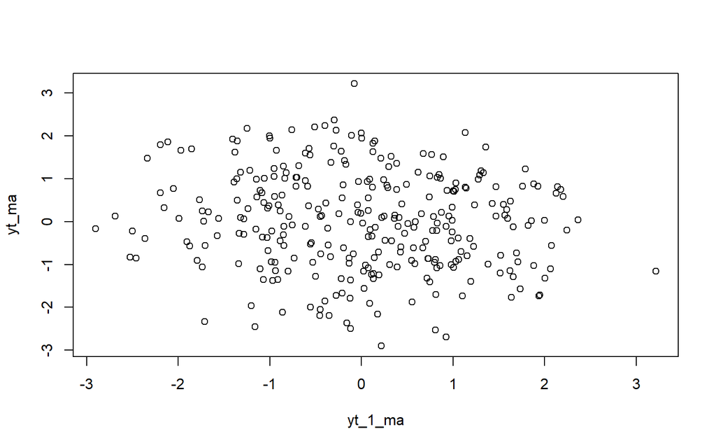

```r
plot(y=yt_ma,x=yt_1_ma)
```

Berdasarkan scatterplot tersebut, dapat dilihat bahwa terdapat kecenderungan hubungan negatif yang sangat lemah cenderung tidak berpola antara $Y_t$ dengan $Y_{t-1}$. Hal tersebut dibuktikan dengan nilai korelasi yang negatif dan nilai yang kecil:

```r
cor(yt_ma,yt_1_ma)
```

```
## [1] -0.1177111
```

Korelasi antara $Y_t$ dengan $Y_{t-1}$ dari hasil simulasi cukup dekat dengan teori, meskipun sedikit lebih kecil yang jika berdasarkan teori:

$$\rho_1=\frac{-\theta_1+\theta_1\theta_2}{1+\theta_1^2+\theta_2^2}=\frac{-0.4+0.4\times0.6}{1+0.4^2+0.6^2}=-0.105$$

### Korelasi antara $Y_t$ dengan $Y_{t-2}$

```r
yt_ma2 <- ma[-c(1,2)]
yt_ma2
```

```
##   [1]  0.589439802 -0.003805205  0.192585563 -1.246277987  2.177726120
##   [6]  0.746196970 -1.407377246  1.927853926  0.821811712 -0.209096611
##  [11] -1.669597098  0.223940757  0.091606999  0.991868139 -0.242080399
##  [16]  0.177135651 -2.153530986  0.323799884  1.518703978 -0.787047283
##  [21]  0.114631796 -0.337906117 -0.817485677  1.137010273  2.076258194
##  [26] -0.553056849 -1.989941189  0.073907119 -1.081906579  0.670795571
##  [31] -0.611200381  1.595782007  0.074934998 -0.353205886 -2.194623816
##  [36]  0.674758359  1.585470846  0.278618203  0.849269573  1.101426476
##  [41] -1.733282151 -1.064294911  0.441748508  0.409717666  0.092625951
##  [46] -1.904204710 -0.467787973  0.290330141  0.790376191  0.113542902
##  [51] -1.236442612  0.298595735  1.277723127  0.983754445 -1.006947643
##  [56]  0.363419048  0.074350380  0.549655948 -0.908778737 -1.353962623
##  [61]  1.881542057  0.875372173  0.219616306 -2.900902898 -0.169420016
##  [66]  1.330991009  1.136354195  0.806932731 -2.523990878 -0.835794093
##  [71]  1.008395032 -1.071124439 -1.354284687  0.493245076  0.866668438
```

[output cut: 45 more lines]

```r
yt_2_ma <- ma[-c(299,300)]
yt_2_ma
```

```
##   [1] -0.511675097  2.204670039  0.589439802 -0.003805205  0.192585563
##   [6] -1.246277987  2.177726120  0.746196970 -1.407377246  1.927853926
##  [11]  0.821811712 -0.209096611 -1.669597098  0.223940757  0.091606999
##  [16]  0.991868139 -0.242080399  0.177135651 -2.153530986  0.323799884
##  [21]  1.518703978 -0.787047283  0.114631796 -0.337906117 -0.817485677
##  [26]  1.137010273  2.076258194 -0.553056849 -1.989941189  0.073907119
##  [31] -1.081906579  0.670795571 -0.611200381  1.595782007  0.074934998
##  [36] -0.353205886 -2.194623816  0.674758359  1.585470846  0.278618203
##  [41]  0.849269573  1.101426476 -1.733282151 -1.064294911  0.441748508
##  [46]  0.409717666  0.092625951 -1.904204710 -0.467787973  0.290330141
##  [51]  0.790376191  0.113542902 -1.236442612  0.298595735  1.277723127
##  [56]  0.983754445 -1.006947643  0.363419048  0.074350380  0.549655948
##  [61] -0.908778737 -1.353962623  1.881542057  0.875372173  0.219616306
##  [66] -2.900902898 -0.169420016  1.330991009  1.136354195  0.806932731
##  [71] -2.523990878 -0.835794093  1.008395032 -1.071124439 -1.354284687
```

[output cut: 45 more lines]

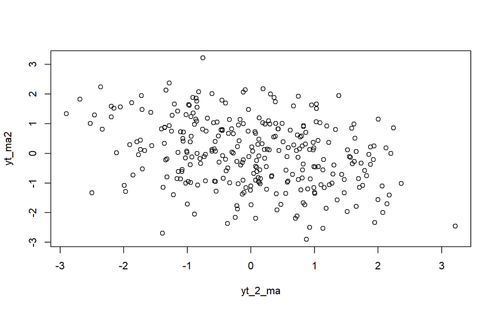

```r
plot(y=yt_ma2,x=yt_2_ma)
```

Berdasarkan scatterplot, dapat dilihat bahwa terdapat hubungan negatif antara $Y_t$ dengan $Y_{t-2}$.

```r
cor(yt_ma2,yt_2_ma)
```

```
## [1] -0.3090718
```

Korelasi antara $Y_t$ dengan $Y_{t-2}$ dari hasil simulasi juga cukup dekat dengan teori, meskipun lebih besar dengan perhitungan teoritis yaitu:

$$\rho_2=\frac{-\theta_2}{1+\theta_1^2+\theta_2^2}=\frac{-0.6}{1+0.4^2+0.6^2}=-0.394$$

### Korelasi antara $Y_t$ dengan $Y_{t-3}$

```r
yt_ma3 <- ma[-c(1,2,3)]
yt_ma3
```

```
##   [1] -0.003805205  0.192585563 -1.246277987  2.177726120  0.746196970
##   [6] -1.407377246  1.927853926  0.821811712 -0.209096611 -1.669597098
##  [11]  0.223940757  0.091606999  0.991868139 -0.242080399  0.177135651
##  [16] -2.153530986  0.323799884  1.518703978 -0.787047283  0.114631796
##  [21] -0.337906117 -0.817485677  1.137010273  2.076258194 -0.553056849
##  [26] -1.989941189  0.073907119 -1.081906579  0.670795571 -0.611200381
##  [31]  1.595782007  0.074934998 -0.353205886 -2.194623816  0.674758359
##  [36]  1.585470846  0.278618203  0.849269573  1.101426476 -1.733282151
##  [41] -1.064294911  0.441748508  0.409717666  0.092625951 -1.904204710
##  [46] -0.467787973  0.290330141  0.790376191  0.113542902 -1.236442612
##  [51]  0.298595735  1.277723127  0.983754445 -1.006947643  0.363419048
##  [56]  0.074350380  0.549655948 -0.908778737 -1.353962623  1.881542057
##  [61]  0.875372173  0.219616306 -2.900902898 -0.169420016  1.330991009
##  [66]  1.136354195  0.806932731 -2.523990878 -0.835794093  1.008395032
##  [71] -1.071124439 -1.354284687  0.493245076  0.866668438  1.014284226
```

[output cut: 45 more lines]

```r
yt_3_ma <- ma[-c(288, 299,300)]
yt_3_ma
```

```
##   [1] -0.511675097  2.204670039  0.589439802 -0.003805205  0.192585563
##   [6] -1.246277987  2.177726120  0.746196970 -1.407377246  1.927853926
##  [11]  0.821811712 -0.209096611 -1.669597098  0.223940757  0.091606999
##  [16]  0.991868139 -0.242080399  0.177135651 -2.153530986  0.323799884
##  [21]  1.518703978 -0.787047283  0.114631796 -0.337906117 -0.817485677
##  [26]  1.137010273  2.076258194 -0.553056849 -1.989941189  0.073907119
##  [31] -1.081906579  0.670795571 -0.611200381  1.595782007  0.074934998
##  [36] -0.353205886 -2.194623816  0.674758359  1.585470846  0.278618203
##  [41]  0.849269573  1.101426476 -1.733282151 -1.064294911  0.441748508
##  [46]  0.409717666  0.092625951 -1.904204710 -0.467787973  0.290330141
##  [51]  0.790376191  0.113542902 -1.236442612  0.298595735  1.277723127
##  [56]  0.983754445 -1.006947643  0.363419048  0.074350380  0.549655948
##  [61] -0.908778737 -1.353962623  1.881542057  0.875372173  0.219616306
##  [66] -2.900902898 -0.169420016  1.330991009  1.136354195  0.806932731
##  [71] -2.523990878 -0.835794093  1.008395032 -1.071124439 -1.354284687
```

[output cut: 45 more lines]

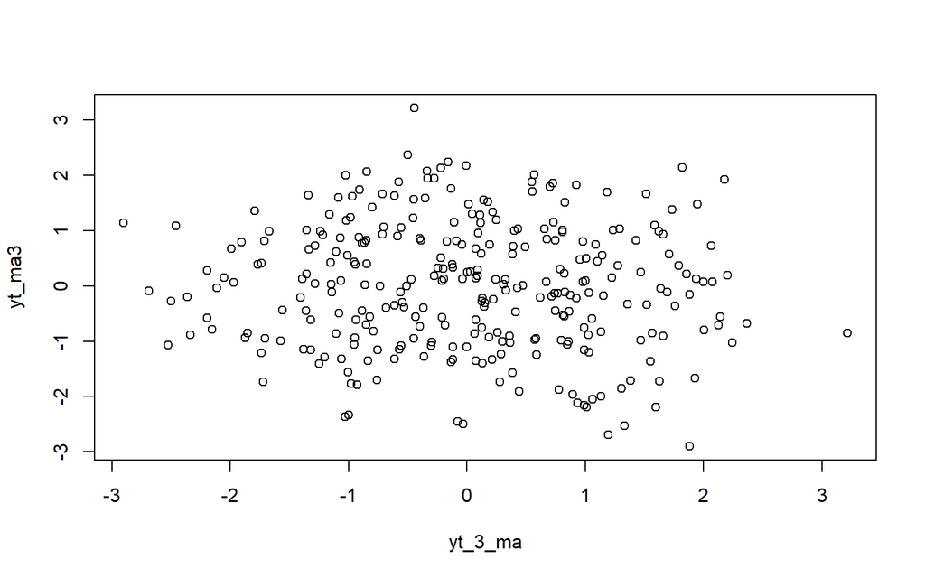

```r
plot(y=yt_ma3,x=yt_3_ma)
```

Berdasarkan scatterplot tersebut, terlihat bahwa $Y_t$ dan $Y_{t-3}$ sudah menunjukkan pola yang tidak beraturan atau bisa disebut tidak berpola.

```r
cor(yt_ma3,yt_3_ma)
```

```
## [1] -0.07410264
```

Korelasi antara $Y_t$ dengan $Y_{t-3}$ dari hasil simulasi hampir mendekati nilai teoritis yang menyatakan bahwa $\rho_k=0$ untuk k>q.

## Kesimpulan

# Model AR(2)

Dalam kasus ini, akan dibangkitkan suatu data dengan model AR(2) sebanyak 300 data yang memiliki nilai $\phi_1 = 0.5$ dan $\phi_2 = 0.2$. Rumusan model tersebut adalah sebagai berikut:

$$Y_t = e_t+0.5Y_{t-1}+0.2Y_{t-2}$$

```r
set.seed(1026)
ar <- c(1:300)
ar[1] <- wn[1]
ar[2] <- wn[2] + 0.5 * ar[1]
```

```r
for (i in 3:300) {
  ar[i] <- wn[i] + 0.5 * ar[i-1] + 0.2 * ar[i-2]
}
ar
```

```
##   [1] -0.51167510 -1.67106479 -1.22152357 -1.91137875 -1.56416382 -3.13614595
##   [7] -0.71039677 -0.95109999 -1.31017018  0.82432905  1.22427136  1.99934171
##  [13]  0.70834864  1.49691696  0.95717903  2.24238595  1.69654410  2.50609884
##  [19]  0.15291629  1.05131078  1.40073060  0.74555667  1.20822311  0.53839376
##  [25] -0.05939663  0.85799798  2.46324199  2.13662320  1.09205325  1.29973725
##  [31] -0.36441696  0.45128764 -1.04863823  0.90529016  0.13275394  0.65377476
##  [37] -1.74474784 -0.66233115 -0.32184078  0.17611402  1.27572330  2.55702509
##  [43]  1.30517198  1.13866639  1.12489512  1.30251474  1.35051242 -0.47133480
##  [49] -0.71162485 -1.30242959 -0.79173962 -1.05350290 -2.07932077 -1.74774208
##  [55] -1.04749735 -0.09107618 -0.80375414  0.19317266 -0.07373808  0.91555099
##  [61] -0.10598081 -0.89517501  0.67323526  0.87458549  1.76356860 -0.93734826
##  [67] -0.36802300 -0.33774498  0.75613402  1.53713689 -0.51438141 -0.62325676
##  [73] -0.53601300 -1.91648168 -3.10216266 -3.17011458 -3.05514768 -2.22861782
##  [79] -1.55934482 -1.65486891 -3.40622340 -1.40840412 -1.26881818 -1.06987066
##  [85] -0.41488966 -0.21723864  1.99481623  0.92116326  1.79021270  1.27218398
```

[output cut: 35 more lines]

Pembangkitan model AR(2) juga dapat dilakukan dengan menerapkan fungsi `arima.sim()`

```r
ar2 <- arima.sim(list(order=c(2,0,0), ar=c(0.5,0.2)), n=300)
ar2
```

[output not shown]

[output cut: 39 more lines]

## Plot Time Series

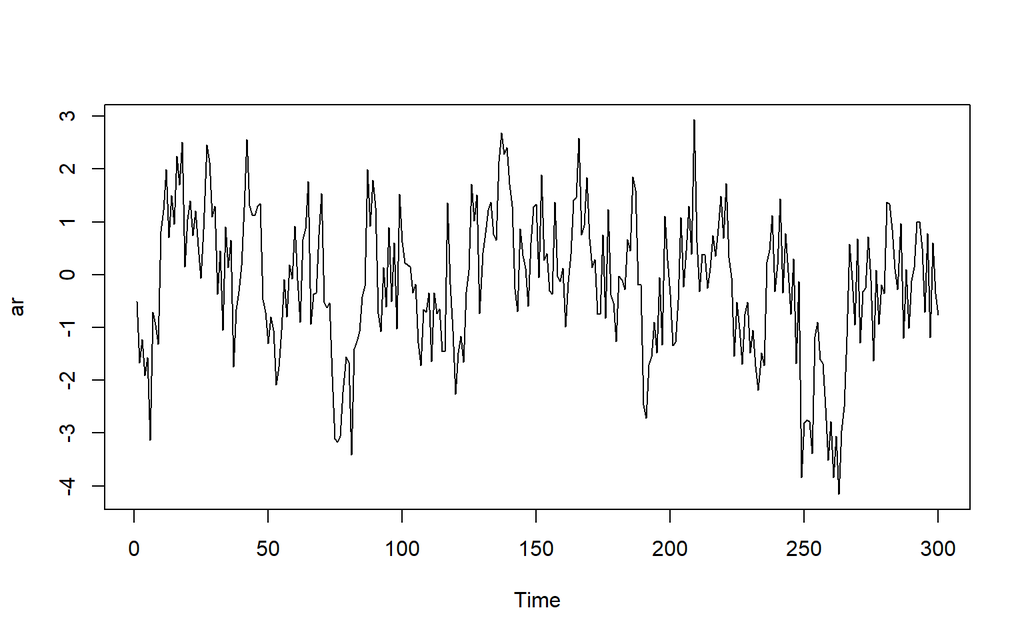

```r
ts.plot(ar)
```

Berdasarkan plot time series tersebut terlihat bahwa data cenderung stasioner pada rataan.

## Plot ACF

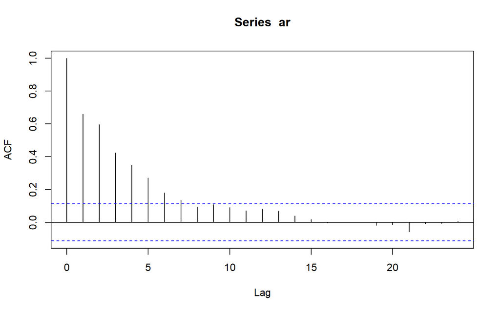

```r
acf(ar)
```

## Plot PACF

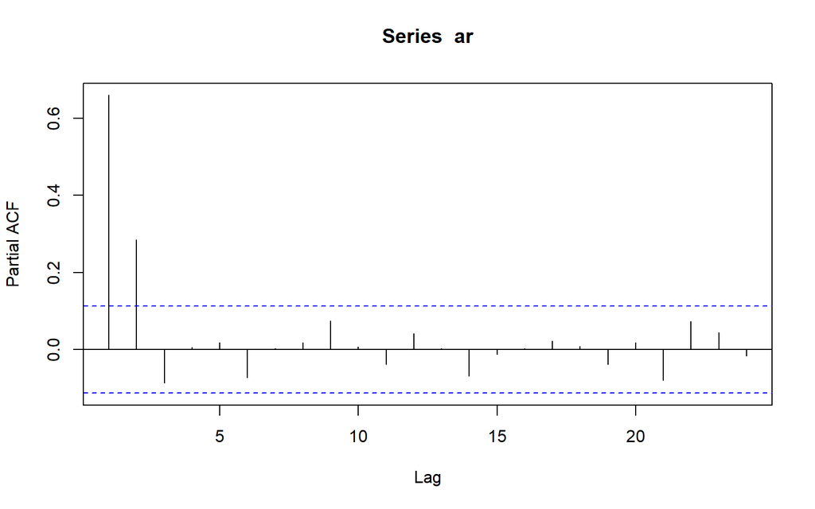

```r
pacf(ar)
```

Berdasarkan plot PACF tersebut, terlihat bahwa plot PACF *cuts off* pada lag kedua sesuai dengan model AR(2).

## Plot EACF

```r
TSA::eacf(ar)
```

```
## AR/MA
##   0 1 2 3 4 5 6 7 8 9 10 11 12 13
## 0 x x x x x x x o o o o  o  o  o
## 1 x x x o o o o o o o o  o  o  o
## 2 x o o o o o o o o o o  o  o  o
## 3 o x o o o o o o o o o  o  o  o
## 4 x o o x o o o o o o o  o  o  o
## 5 x x x x o o o o o o o  o  o  o
## 6 o x x o o o o o o o o  o  o  o
## 7 o o x x o o o o o o o  o  o  o
```

Berdasarkan pola segitiga nol pada plot EACF, terlihat bahwa segitiga nol berada pada ordo AR(2) dan ordo MA(1) bisa juga ordo AR(1) dan ordo MA(3).

## Scatterplot Antar Lag

### Korelasi antara $Y_t$ dengan $Y_{t-1}$

```r
yt_ar <- ar[-1]
yt_ar
```

```
##   [1] -1.67106479 -1.22152357 -1.91137875 -1.56416382 -3.13614595 -0.71039677
##   [7] -0.95109999 -1.31017018  0.82432905  1.22427136  1.99934171  0.70834864
##  [13]  1.49691696  0.95717903  2.24238595  1.69654410  2.50609884  0.15291629
##  [19]  1.05131078  1.40073060  0.74555667  1.20822311  0.53839376 -0.05939663
##  [25]  0.85799798  2.46324199  2.13662320  1.09205325  1.29973725 -0.36441696
##  [31]  0.45128764 -1.04863823  0.90529016  0.13275394  0.65377476 -1.74474784
##  [37] -0.66233115 -0.32184078  0.17611402  1.27572330  2.55702509  1.30517198
##  [43]  1.13866639  1.12489512  1.30251474  1.35051242 -0.47133480 -0.71162485
##  [49] -1.30242959 -0.79173962 -1.05350290 -2.07932077 -1.74774208 -1.04749735
##  [55] -0.09107618 -0.80375414  0.19317266 -0.07373808  0.91555099 -0.10598081
##  [61] -0.89517501  0.67323526  0.87458549  1.76356860 -0.93734826 -0.36802300
##  [67] -0.33774498  0.75613402  1.53713689 -0.51438141 -0.62325676 -0.53601300
##  [73] -1.91648168 -3.10216266 -3.17011458 -3.05514768 -2.22861782 -1.55934482
##  [79] -1.65486891 -3.40622340 -1.40840412 -1.26881818 -1.06987066 -0.41488966
##  [85] -0.21723864  1.99481623  0.92116326  1.79021270  1.27218398 -0.73080802
```

[output cut: 35 more lines]

```r
yt_1_ar <- ar[-300]
yt_1_ar
```

```
##   [1] -0.51167510 -1.67106479 -1.22152357 -1.91137875 -1.56416382 -3.13614595
##   [7] -0.71039677 -0.95109999 -1.31017018  0.82432905  1.22427136  1.99934171
##  [13]  0.70834864  1.49691696  0.95717903  2.24238595  1.69654410  2.50609884
##  [19]  0.15291629  1.05131078  1.40073060  0.74555667  1.20822311  0.53839376
##  [25] -0.05939663  0.85799798  2.46324199  2.13662320  1.09205325  1.29973725
##  [31] -0.36441696  0.45128764 -1.04863823  0.90529016  0.13275394  0.65377476
##  [37] -1.74474784 -0.66233115 -0.32184078  0.17611402  1.27572330  2.55702509
##  [43]  1.30517198  1.13866639  1.12489512  1.30251474  1.35051242 -0.47133480
##  [49] -0.71162485 -1.30242959 -0.79173962 -1.05350290 -2.07932077 -1.74774208
##  [55] -1.04749735 -0.09107618 -0.80375414  0.19317266 -0.07373808  0.91555099
##  [61] -0.10598081 -0.89517501  0.67323526  0.87458549  1.76356860 -0.93734826
##  [67] -0.36802300 -0.33774498  0.75613402  1.53713689 -0.51438141 -0.62325676
##  [73] -0.53601300 -1.91648168 -3.10216266 -3.17011458 -3.05514768 -2.22861782
##  [79] -1.55934482 -1.65486891 -3.40622340 -1.40840412 -1.26881818 -1.06987066
##  [85] -0.41488966 -0.21723864  1.99481623  0.92116326  1.79021270  1.27218398
```

[output cut: 35 more lines]

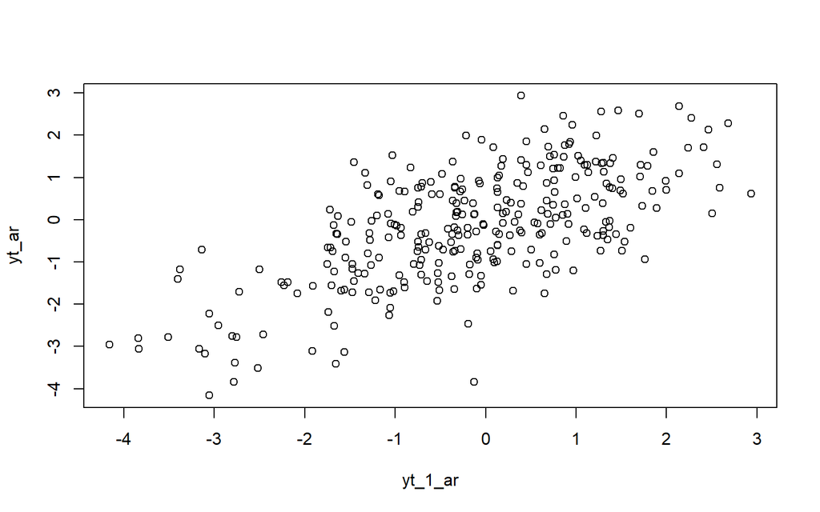

```r
plot(y=yt_ar,x=yt_1_ar)
```

Berdasarkan scatterplot tersebut, terlihat bahwa terdapat hubungan positif antara $Y_t$ dengan $Y_{t-1}$.

```r
cor(yt_ar,yt_1_ar)
```

```
## [1] 0.6602724
```

Korelasi antara $Y_t$ dengan $Y_{t-1}$ dari hasil simulasi hampir mendekati perhitungan teoritis yaitu

$$\rho_1=\frac{\phi_1}{1-\phi_2}=\frac{0.5}{1-0.2}=0.625$$

### Korelasi antara $Y_t$ dengan $Y_{t-2}$

```r
yt_ar2 <- ar[-c(1,2)]
yt_ar2
```

```
##   [1] -1.22152357 -1.91137875 -1.56416382 -3.13614595 -0.71039677 -0.95109999
##   [7] -1.31017018  0.82432905  1.22427136  1.99934171  0.70834864  1.49691696
##  [13]  0.95717903  2.24238595  1.69654410  2.50609884  0.15291629  1.05131078
##  [19]  1.40073060  0.74555667  1.20822311  0.53839376 -0.05939663  0.85799798
##  [25]  2.46324199  2.13662320  1.09205325  1.29973725 -0.36441696  0.45128764
##  [31] -1.04863823  0.90529016  0.13275394  0.65377476 -1.74474784 -0.66233115
##  [37] -0.32184078  0.17611402  1.27572330  2.55702509  1.30517198  1.13866639
##  [43]  1.12489512  1.30251474  1.35051242 -0.47133480 -0.71162485 -1.30242959
##  [49] -0.79173962 -1.05350290 -2.07932077 -1.74774208 -1.04749735 -0.09107618
##  [55] -0.80375414  0.19317266 -0.07373808  0.91555099 -0.10598081 -0.89517501
##  [61]  0.67323526  0.87458549  1.76356860 -0.93734826 -0.36802300 -0.33774498
##  [67]  0.75613402  1.53713689 -0.51438141 -0.62325676 -0.53601300 -1.91648168
##  [73] -3.10216266 -3.17011458 -3.05514768 -2.22861782 -1.55934482 -1.65486891
##  [79] -3.40622340 -1.40840412 -1.26881818 -1.06987066 -0.41488966 -0.21723864
##  [85]  1.99481623  0.92116326  1.79021270  1.27218398 -0.73080802 -1.08011819
```

[output cut: 35 more lines]

```r
yt_2_ar <- ar[-c(299,300)]
yt_2_ar
```

```
##   [1] -0.51167510 -1.67106479 -1.22152357 -1.91137875 -1.56416382 -3.13614595
##   [7] -0.71039677 -0.95109999 -1.31017018  0.82432905  1.22427136  1.99934171
##  [13]  0.70834864  1.49691696  0.95717903  2.24238595  1.69654410  2.50609884
##  [19]  0.15291629  1.05131078  1.40073060  0.74555667  1.20822311  0.53839376
##  [25] -0.05939663  0.85799798  2.46324199  2.13662320  1.09205325  1.29973725
##  [31] -0.36441696  0.45128764 -1.04863823  0.90529016  0.13275394  0.65377476
##  [37] -1.74474784 -0.66233115 -0.32184078  0.17611402  1.27572330  2.55702509
##  [43]  1.30517198  1.13866639  1.12489512  1.30251474  1.35051242 -0.47133480
##  [49] -0.71162485 -1.30242959 -0.79173962 -1.05350290 -2.07932077 -1.74774208
##  [55] -1.04749735 -0.09107618 -0.80375414  0.19317266 -0.07373808  0.91555099
##  [61] -0.10598081 -0.89517501  0.67323526  0.87458549  1.76356860 -0.93734826
##  [67] -0.36802300 -0.33774498  0.75613402  1.53713689 -0.51438141 -0.62325676
##  [73] -0.53601300 -1.91648168 -3.10216266 -3.17011458 -3.05514768 -2.22861782
##  [79] -1.55934482 -1.65486891 -3.40622340 -1.40840412 -1.26881818 -1.06987066
##  [85] -0.41488966 -0.21723864  1.99481623  0.92116326  1.79021270  1.27218398
```

[output cut: 35 more lines]

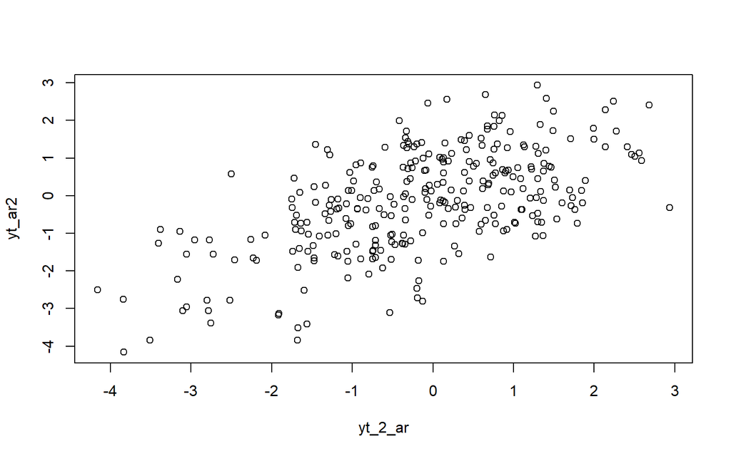

```r
plot(y=yt_ar2,x=yt_2_ar)
```

Berdasarkan scatterplot tersebut, terlihat bahwa terdapat hubungan positif antara $Y_t$ dengan $Y_{t-2}$.

```r
cor(yt_ar2,yt_2_ar)
```

```
## [1] 0.5975263
```

Korelasi antara $Y_t$ dengan $Y_{t-2}$ dari hasil simulasi hampir mendekati perhitungan teoritis yaitu:

$$\rho_2=\phi_1\rho_{k-1}+\phi_2\rho_{k-2}=\frac{\phi_2(1-\phi_2)+\phi_1^2}{1-\phi_2}=\frac{0.2(1-0.2)+0.5^2}{1-0.2}=0.5125$$

### Korelasi antara $Y_t$ dengan $Y_{t-3}$

```r
yt_ar3 <- ar[-c(1,2,3)]
yt_ar3
```

```
##   [1] -1.91137875 -1.56416382 -3.13614595 -0.71039677 -0.95109999 -1.31017018
##   [7]  0.82432905  1.22427136  1.99934171  0.70834864  1.49691696  0.95717903
##  [13]  2.24238595  1.69654410  2.50609884  0.15291629  1.05131078  1.40073060
##  [19]  0.74555667  1.20822311  0.53839376 -0.05939663  0.85799798  2.46324199
##  [25]  2.13662320  1.09205325  1.29973725 -0.36441696  0.45128764 -1.04863823
##  [31]  0.90529016  0.13275394  0.65377476 -1.74474784 -0.66233115 -0.32184078
##  [37]  0.17611402  1.27572330  2.55702509  1.30517198  1.13866639  1.12489512
##  [43]  1.30251474  1.35051242 -0.47133480 -0.71162485 -1.30242959 -0.79173962
##  [49] -1.05350290 -2.07932077 -1.74774208 -1.04749735 -0.09107618 -0.80375414
##  [55]  0.19317266 -0.07373808  0.91555099 -0.10598081 -0.89517501  0.67323526
##  [61]  0.87458549  1.76356860 -0.93734826 -0.36802300 -0.33774498  0.75613402
##  [67]  1.53713689 -0.51438141 -0.62325676 -0.53601300 -1.91648168 -3.10216266
##  [73] -3.17011458 -3.05514768 -2.22861782 -1.55934482 -1.65486891 -3.40622340
##  [79] -1.40840412 -1.26881818 -1.06987066 -0.41488966 -0.21723864  1.99481623
##  [85]  0.92116326  1.79021270  1.27218398 -0.73080802 -1.08011819  0.13297084
```

[output cut: 35 more lines]

```r
yt_3_ar <- ar[-c(298,299,300)]
yt_3_ar
```

```
##   [1] -0.51167510 -1.67106479 -1.22152357 -1.91137875 -1.56416382 -3.13614595
##   [7] -0.71039677 -0.95109999 -1.31017018  0.82432905  1.22427136  1.99934171
##  [13]  0.70834864  1.49691696  0.95717903  2.24238595  1.69654410  2.50609884
##  [19]  0.15291629  1.05131078  1.40073060  0.74555667  1.20822311  0.53839376
##  [25] -0.05939663  0.85799798  2.46324199  2.13662320  1.09205325  1.29973725
##  [31] -0.36441696  0.45128764 -1.04863823  0.90529016  0.13275394  0.65377476
##  [37] -1.74474784 -0.66233115 -0.32184078  0.17611402  1.27572330  2.55702509
##  [43]  1.30517198  1.13866639  1.12489512  1.30251474  1.35051242 -0.47133480
##  [49] -0.71162485 -1.30242959 -0.79173962 -1.05350290 -2.07932077 -1.74774208
##  [55] -1.04749735 -0.09107618 -0.80375414  0.19317266 -0.07373808  0.91555099
##  [61] -0.10598081 -0.89517501  0.67323526  0.87458549  1.76356860 -0.93734826
##  [67] -0.36802300 -0.33774498  0.75613402  1.53713689 -0.51438141 -0.62325676
##  [73] -0.53601300 -1.91648168 -3.10216266 -3.17011458 -3.05514768 -2.22861782
##  [79] -1.55934482 -1.65486891 -3.40622340 -1.40840412 -1.26881818 -1.06987066
##  [85] -0.41488966 -0.21723864  1.99481623  0.92116326  1.79021270  1.27218398
```

[output cut: 35 more lines]

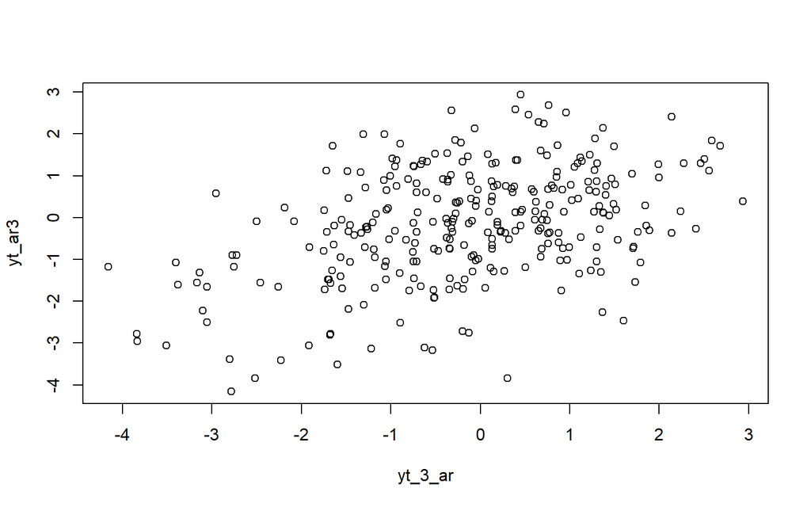

```r
plot(y=yt_ar3,x=yt_3_ar)
```

Berdasarkan scatterplot tersebut, terlihat bahwa terdapat hubungan positif yang sedikit lemah antara $Y_t$ dengan $Y_{t-3}$.

```r
cor(yt_ar3,yt_3_ar)
```

```
## [1] 0.4256933
```

Korelasi antara $Y_t$ dengan $Y_{t-3}$ dari hasil simulasi sedkit mendekati perhitungan teoritis yaitu

$$\rho_3=\phi_1\rho_{k-1}+\phi_2\rho_{k-2}=\phi_1\rho_2+\phi_2\rho_1=0.5\times0.5125+0.2\times0.625=0.38125$$

## Kesimpulan

# Model ARMA(2,2)

Dalam kasus ini, akan dibangkitkan suatu data dengan model ARMA(2,2) sebanyak 300 data yang memiliki nilai $\phi_1 = 0.5$ dan $\phi_2 = 0.2$ serta $\theta_1 = 0.4$ dan $\theta_2 = 0.6$. Rumusan model tersebut adalah sebagai berikut:

$$Y_t =
0.5Y_{t-1}+0.2Y_{t-2}+e_t-0.4_{t-1}-0.6_{t-2}$$

```r
set.seed(1026)
phi1 = 0.5
phi2 = 0.2
theta1 = 0.4
theta2 = 0.6

y.arma=c(1:300)
for (i in 3:300){y.arma[i] = phi1*y.arma[i-1] + phi2*y.arma[i-2] +
                 wn[i] - theta1*wn[i-1] - theta2*wn[i-2]}
y.arma
```

```
##   [1]  1.0000000000  2.0000000000  1.7894398017  1.2909146956  1.1959308710
##   [6] -0.3901296125  2.2218474876  1.7790947918 -0.0734603521  2.2469427086
##  [11]  1.9305909954  1.2055874281 -0.6806851849  0.1247156501  0.0178277870
##  [16]  1.0257251625  0.2743477398  0.5194545534 -1.8389341611 -0.4917762858
##  [21]  0.9050290027 -0.4328880386  0.0791935767 -0.3848869361 -0.9940904293
##  [26]  0.5629876706  2.1589339437  0.6390076573 -1.2386505718 -0.4176166355
##  [31] -1.5384450113 -0.1819502620 -1.0098645146  1.0544596968  0.4001919434
##  [36]  0.0577820255 -2.0856944146 -0.3565324428  0.9900657421  0.7023445856
##  [41]  1.3984550141  1.9411228997 -0.4830296979 -0.9175851797 -0.1136500211
##  [46]  0.1693756193  0.1545837561 -1.7930377086 -1.3333900763 -0.7349724386
##  [51]  0.1562119566  0.0446543922 -1.1828730250 -0.2839098993  0.8991935722
##  [56]  1.3765692516 -0.1388243027  0.5693207470  0.3312458926  0.8291430442
##  [61] -0.4279580364 -1.4021130328  1.0948939331  1.1423965330  1.0097933591
##  [66] -2.1675269122 -1.0512248000  0.3718732266  1.1120458486  1.4373303011
##  [71] -1.5829165576 -1.3397863120  0.0219185642 -1.3281224190 -2.0139621833
```

[output cut: 45 more lines]

Pembangkitan model ARMA(2,2) juga dapat dilakukan dengan menerapkan fungsi `arima.sim()`

```r
arma22 <- arima.sim(list(order=c(2,0,2), ar = c(0.5,0.2), ma = c(0.4,0.6)), n=300)
arma22
```

```
## Time Series:
## Start = 1
## End = 300
## Frequency = 1
##   [1]  3.63800919  3.42563146  3.01928242  0.81128161  1.08579906 -1.08644108
##   [7]  0.75686076 -0.13411983  1.25019765 -1.40347334 -0.96787987 -1.63355672
##  [13] -0.34997126  1.15310235  3.17301172  3.09343803  3.19496703  2.36347766
##  [19]  2.43568238  2.54646283  0.85038469 -0.08984700 -1.86987712 -1.73968386
##  [25] -2.15165459 -2.97576424 -3.21157101 -2.99418580 -1.55871973 -1.46868253
##  [31] -0.18297433 -0.47872121  1.00195957  0.21599691 -0.38823661  0.25157687
##  [37]  0.60677467  2.51734401  0.29283052  0.31517889 -1.04736311  0.40022225
##  [43]  1.63694353  0.55415377  0.09327283 -1.09394454 -2.50484093 -4.19036313
##  [49] -5.56086865 -6.18449110 -5.35274563 -4.28388056 -3.61577753 -5.00377785
##  [55] -3.76381483 -3.87591387 -2.42244040 -1.60412883 -1.02511690  1.65898697
##  [61]  1.58874657  3.35556774  2.54096701  0.85219319 -0.60913101 -0.73756124
```

[output cut: 39 more lines]

## Plot Time Series

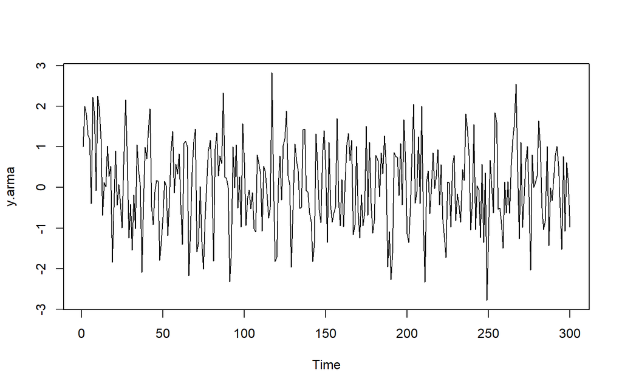

```r
ts.plot(y.arma)
```

Berdasarkan plot time series tersebut, terlihat bahwa model ARMA(2,2) stasioner dalam rataan.

## Plot ACF

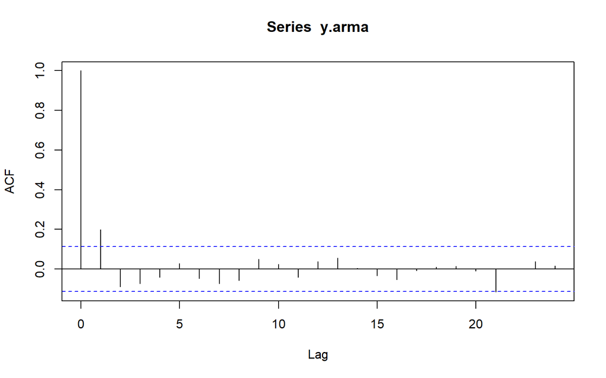

```r
acf(y.arma)
```

Berdasarkan plot ACF tersebut, terlihat bahwa model ARMA(2,2) hasil simulasi memiliki plot ACF yang *cuts off*.

## Plot PACF

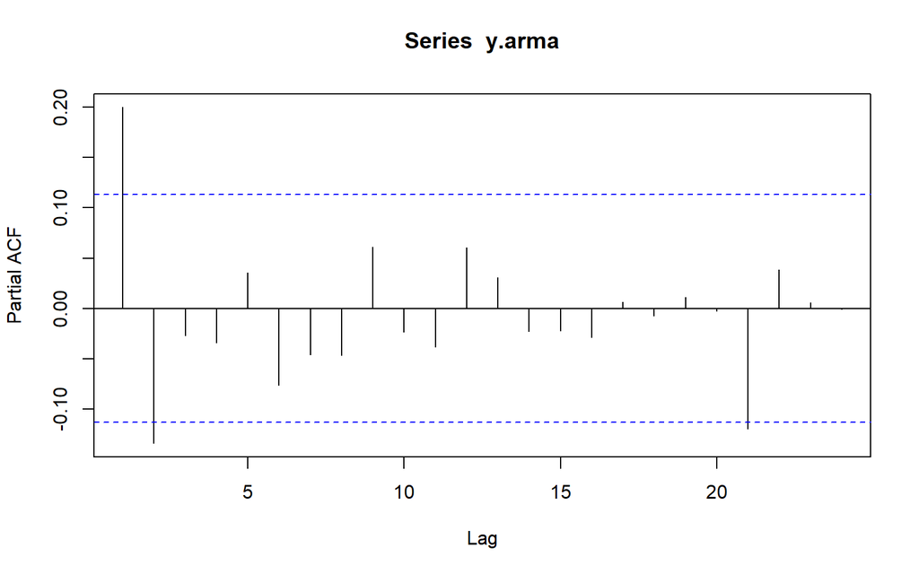

```r
pacf(y.arma)
```

Berdasarkan plot PACF tersebut, terlihat bahwa model ARMA(2,2) hasil simulasi memiliki plot PACF yang *cuts off*.

## Plot EACF

```r
TSA::eacf(y.arma)
```

```
## AR/MA
##   0 1 2 3 4 5 6 7 8 9 10 11 12 13
## 0 x o o o o o o o o o o  o  o  o
## 1 x x o o o o o o o o o  o  o  o
## 2 x x o o o o o o o o o  o  o  o
## 3 x x o o o o o o o o o  o  o  o
## 4 x x o x o o o o o o o  o  o  o
## 5 x x x x o o o o o o o  o  o  o
## 6 x x x x x o o o o o o  o  o  o
## 7 x o x x o o x x o o o  o  o  o
```

Berdasarkan pola segitiga nol pada plot EACF, terlihat bahwa segitiga nol berada pada ordo AR(0) dan ordo MA(1).

## Scatterplot Antar Lag

### Korelasi antara $Y_t$ dengan $Y_{t-1}$

```r
yt_arma <- y.arma[-1]
yt_arma
```

```
##   [1]  2.0000000000  1.7894398017  1.2909146956  1.1959308710 -0.3901296125
##   [6]  2.2218474876  1.7790947918 -0.0734603521  2.2469427086  1.9305909954
##  [11]  1.2055874281 -0.6806851849  0.1247156501  0.0178277870  1.0257251625
##  [16]  0.2743477398  0.5194545534 -1.8389341611 -0.4917762858  0.9050290027
##  [21] -0.4328880386  0.0791935767 -0.3848869361 -0.9940904293  0.5629876706
##  [26]  2.1589339437  0.6390076573 -1.2386505718 -0.4176166355 -1.5384450113
##  [31] -0.1819502620 -1.0098645146  1.0544596968  0.4001919434  0.0577820255
##  [36] -2.0856944146 -0.3565324428  0.9900657421  0.7023445856  1.3984550141
##  [41]  1.9411228997 -0.4830296979 -0.9175851797 -0.1136500211  0.1693756193
##  [46]  0.1545837561 -1.7930377086 -1.3333900763 -0.7349724386  0.1562119566
##  [51]  0.0446543922 -1.1828730250 -0.2839098993  0.8991935722  1.3765692516
##  [56] -0.1388243027  0.5693207470  0.3312458926  0.8291430442 -0.4279580364
##  [61] -1.4021130328  1.0948939331  1.1423965330  1.0097933591 -2.1675269122
##  [66] -1.0512248000  0.3718732266  1.1120458486  1.4373303011 -1.5829165576
##  [71] -1.3397863120  0.0219185642 -1.3281224190 -2.0139621833 -0.7793604995
```

[output cut: 45 more lines]

```r
yt_1_arma <- y.arma[-300]
yt_1_arma
```

```
##   [1]  1.0000000000  2.0000000000  1.7894398017  1.2909146956  1.1959308710
##   [6] -0.3901296125  2.2218474876  1.7790947918 -0.0734603521  2.2469427086
##  [11]  1.9305909954  1.2055874281 -0.6806851849  0.1247156501  0.0178277870
##  [16]  1.0257251625  0.2743477398  0.5194545534 -1.8389341611 -0.4917762858
##  [21]  0.9050290027 -0.4328880386  0.0791935767 -0.3848869361 -0.9940904293
##  [26]  0.5629876706  2.1589339437  0.6390076573 -1.2386505718 -0.4176166355
##  [31] -1.5384450113 -0.1819502620 -1.0098645146  1.0544596968  0.4001919434
##  [36]  0.0577820255 -2.0856944146 -0.3565324428  0.9900657421  0.7023445856
##  [41]  1.3984550141  1.9411228997 -0.4830296979 -0.9175851797 -0.1136500211
##  [46]  0.1693756193  0.1545837561 -1.7930377086 -1.3333900763 -0.7349724386
##  [51]  0.1562119566  0.0446543922 -1.1828730250 -0.2839098993  0.8991935722
##  [56]  1.3765692516 -0.1388243027  0.5693207470  0.3312458926  0.8291430442
##  [61] -0.4279580364 -1.4021130328  1.0948939331  1.1423965330  1.0097933591
##  [66] -2.1675269122 -1.0512248000  0.3718732266  1.1120458486  1.4373303011
##  [71] -1.5829165576 -1.3397863120  0.0219185642 -1.3281224190 -2.0139621833
```

[output cut: 45 more lines]

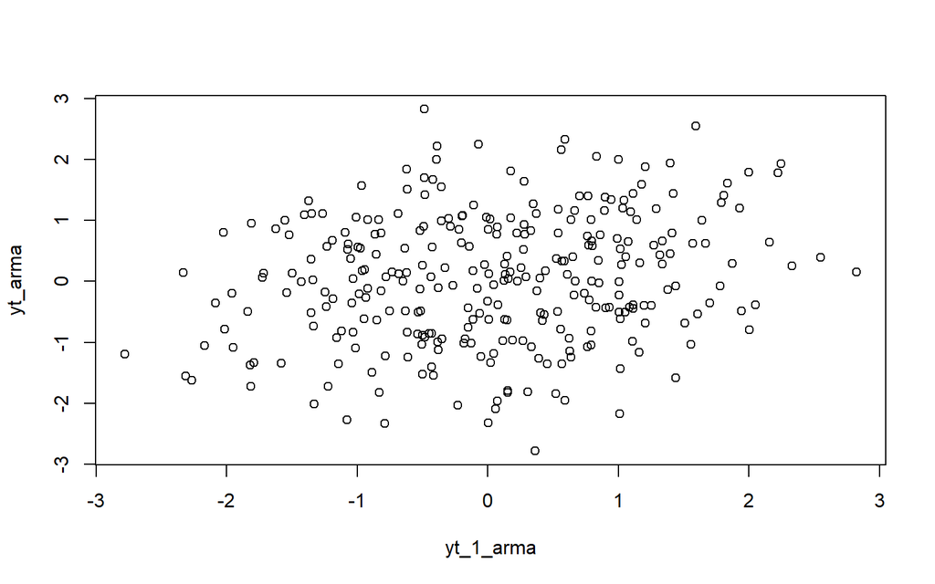

```r
plot(y=yt_arma,x=yt_1_arma)
```

Berdasarkan scatterplot tersebut, terlihat bahwa ada hubungan positif yang cukup lemah antara $Y_t$ dengan $Y_{t-1}$.

```r
cor(yt_arma,yt_1_arma)
```

```
## [1] 0.2003342
```

Korelasi antara $Y_t$ dengan $Y_{t-1}$ dari hasil simulasi jauh berbeda dengan teori, jika berdasarkan teori:

$$\rho_1 = \frac{(1 - \phi_2)\theta_1 + (\phi_1 - \phi_2)\theta_2 +
\phi_1(1 + \theta_1^2 + \theta_2^2)}
{(1 - \phi_2)(1 + \theta_1^2 + \theta_2^2) + 2(\phi_1 -
\phi_2)\theta_1\theta_2}
= \frac{(1 - 0.2)(0.4) + (0.5 - 0.2)(0.6) + 0.5(1 + 0.4^2 + 0.6^2)}
{(1 - 0.2)(1 + 0.4^2 + 0.6^2) + 2(0.5 - 0.2)(0.4)(0.6)}
= \frac{1.26}{1.36} \approx 0.926$$

### Korelasi antara $Y_t$ dengan $Y_{t-2}$

```r
yt_arma <- y.arma[-c(1,2)]
yt_arma
```

```
##   [1]  1.7894398017  1.2909146956  1.1959308710 -0.3901296125  2.2218474876
##   [6]  1.7790947918 -0.0734603521  2.2469427086  1.9305909954  1.2055874281
##  [11] -0.6806851849  0.1247156501  0.0178277870  1.0257251625  0.2743477398
##  [16]  0.5194545534 -1.8389341611 -0.4917762858  0.9050290027 -0.4328880386
##  [21]  0.0791935767 -0.3848869361 -0.9940904293  0.5629876706  2.1589339437
##  [26]  0.6390076573 -1.2386505718 -0.4176166355 -1.5384450113 -0.1819502620
##  [31] -1.0098645146  1.0544596968  0.4001919434  0.0577820255 -2.0856944146
##  [36] -0.3565324428  0.9900657421  0.7023445856  1.3984550141  1.9411228997
##  [41] -0.4830296979 -0.9175851797 -0.1136500211  0.1693756193  0.1545837561
##  [46] -1.7930377086 -1.3333900763 -0.7349724386  0.1562119566  0.0446543922
##  [51] -1.1828730250 -0.2839098993  0.8991935722  1.3765692516 -0.1388243027
##  [56]  0.5693207470  0.3312458926  0.8291430442 -0.4279580364 -1.4021130328
##  [61]  1.0948939331  1.1423965330  1.0097933591 -2.1675269122 -1.0512248000
##  [66]  0.3718732266  1.1120458486  1.4373303011 -1.5829165576 -1.3397863120
##  [71]  0.0219185642 -1.3281224190 -2.0139621833 -0.7793604995  0.0741957520
```

[output cut: 45 more lines]

```r
yt_2_arma <- y.arma[-c(299,300)]
yt_2_arma
```

```
##   [1]  1.0000000000  2.0000000000  1.7894398017  1.2909146956  1.1959308710
##   [6] -0.3901296125  2.2218474876  1.7790947918 -0.0734603521  2.2469427086
##  [11]  1.9305909954  1.2055874281 -0.6806851849  0.1247156501  0.0178277870
##  [16]  1.0257251625  0.2743477398  0.5194545534 -1.8389341611 -0.4917762858
##  [21]  0.9050290027 -0.4328880386  0.0791935767 -0.3848869361 -0.9940904293
##  [26]  0.5629876706  2.1589339437  0.6390076573 -1.2386505718 -0.4176166355
##  [31] -1.5384450113 -0.1819502620 -1.0098645146  1.0544596968  0.4001919434
##  [36]  0.0577820255 -2.0856944146 -0.3565324428  0.9900657421  0.7023445856
##  [41]  1.3984550141  1.9411228997 -0.4830296979 -0.9175851797 -0.1136500211
##  [46]  0.1693756193  0.1545837561 -1.7930377086 -1.3333900763 -0.7349724386
##  [51]  0.1562119566  0.0446543922 -1.1828730250 -0.2839098993  0.8991935722
##  [56]  1.3765692516 -0.1388243027  0.5693207470  0.3312458926  0.8291430442
##  [61] -0.4279580364 -1.4021130328  1.0948939331  1.1423965330  1.0097933591
##  [66] -2.1675269122 -1.0512248000  0.3718732266  1.1120458486  1.4373303011
##  [71] -1.5829165576 -1.3397863120  0.0219185642 -1.3281224190 -2.0139621833
```

[output cut: 45 more lines]

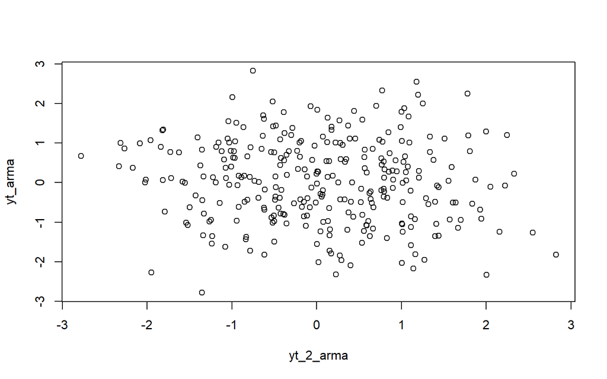

```r
plot(y=yt_arma,x=yt_2_arma)
```

Berdasarkan scatterplot tersebut, terlihat bahwa hubungan cenderung tidak berpola antara $Y_t$ dengan $Y_{t-2}$.

```r
cor(yt_arma,yt_2_arma)
```

```
## [1] -0.08932871
```

Nilai korelasi antara $Y_t$ dengan $Y_{t-2}$ dari hasil simulasi jauh berbeda dengan teori, jika berdasarkan teori:

$$\rho_2 = \frac{(\phi_1 + \theta_1\theta_2)(1 - \phi_2) + (\phi_1^2 -
\phi_2)(1 + \theta_1^2 + \theta_2^2) + \theta_2(\theta_1 +
\phi_1\theta_2)}
{(1 - \phi_2)(1 + \theta_1^2 + \theta_2^2) + 2(\phi_1 -
\phi_2)\theta_1\theta_2}
= \frac{(0.5 + 0.4 \times 0.6)(0.8) + (0.5^2 - 0.2)(1 + 0.4^2 + 0.6^2) +
0.6(0.4 + 0.5 \times 0.6)}
{(1-0.2)(1 + 0.4^2 + 0.6^2) + 2(0.5 - 0.2)(0.4)(0.6)}
= \frac{1.088}{1.36} = 0.8$$

### Korelasi antara $Y_t$ dengan $Y_{t-3}$

```r
yt_arma <- y.arma[-c(1,2,3)]
yt_arma
```

```
##   [1]  1.2909146956  1.1959308710 -0.3901296125  2.2218474876  1.7790947918
##   [6] -0.0734603521  2.2469427086  1.9305909954  1.2055874281 -0.6806851849
##  [11]  0.1247156501  0.0178277870  1.0257251625  0.2743477398  0.5194545534
##  [16] -1.8389341611 -0.4917762858  0.9050290027 -0.4328880386  0.0791935767
##  [21] -0.3848869361 -0.9940904293  0.5629876706  2.1589339437  0.6390076573
##  [26] -1.2386505718 -0.4176166355 -1.5384450113 -0.1819502620 -1.0098645146
##  [31]  1.0544596968  0.4001919434  0.0577820255 -2.0856944146 -0.3565324428
##  [36]  0.9900657421  0.7023445856  1.3984550141  1.9411228997 -0.4830296979
##  [41] -0.9175851797 -0.1136500211  0.1693756193  0.1545837561 -1.7930377086
##  [46] -1.3333900763 -0.7349724386  0.1562119566  0.0446543922 -1.1828730250
##  [51] -0.2839098993  0.8991935722  1.3765692516 -0.1388243027  0.5693207470
##  [56]  0.3312458926  0.8291430442 -0.4279580364 -1.4021130328  1.0948939331
##  [61]  1.1423965330  1.0097933591 -2.1675269122 -1.0512248000  0.3718732266
##  [66]  1.1120458486  1.4373303011 -1.5829165576 -1.3397863120  0.0219185642
##  [71] -1.3281224190 -2.0139621833 -0.7793604995  0.0741957520  0.8955100023
```

[output cut: 45 more lines]

```r
yt_3_arma <- y.arma[-c(298,299,300)]
yt_3_arma
```

```
##   [1]  1.0000000000  2.0000000000  1.7894398017  1.2909146956  1.1959308710
##   [6] -0.3901296125  2.2218474876  1.7790947918 -0.0734603521  2.2469427086
##  [11]  1.9305909954  1.2055874281 -0.6806851849  0.1247156501  0.0178277870
##  [16]  1.0257251625  0.2743477398  0.5194545534 -1.8389341611 -0.4917762858
##  [21]  0.9050290027 -0.4328880386  0.0791935767 -0.3848869361 -0.9940904293
##  [26]  0.5629876706  2.1589339437  0.6390076573 -1.2386505718 -0.4176166355
##  [31] -1.5384450113 -0.1819502620 -1.0098645146  1.0544596968  0.4001919434
##  [36]  0.0577820255 -2.0856944146 -0.3565324428  0.9900657421  0.7023445856
##  [41]  1.3984550141  1.9411228997 -0.4830296979 -0.9175851797 -0.1136500211
##  [46]  0.1693756193  0.1545837561 -1.7930377086 -1.3333900763 -0.7349724386
##  [51]  0.1562119566  0.0446543922 -1.1828730250 -0.2839098993  0.8991935722
##  [56]  1.3765692516 -0.1388243027  0.5693207470  0.3312458926  0.8291430442
##  [61] -0.4279580364 -1.4021130328  1.0948939331  1.1423965330  1.0097933591
##  [66] -2.1675269122 -1.0512248000  0.3718732266  1.1120458486  1.4373303011
##  [71] -1.5829165576 -1.3397863120  0.0219185642 -1.3281224190 -2.0139621833
```

[output cut: 45 more lines]

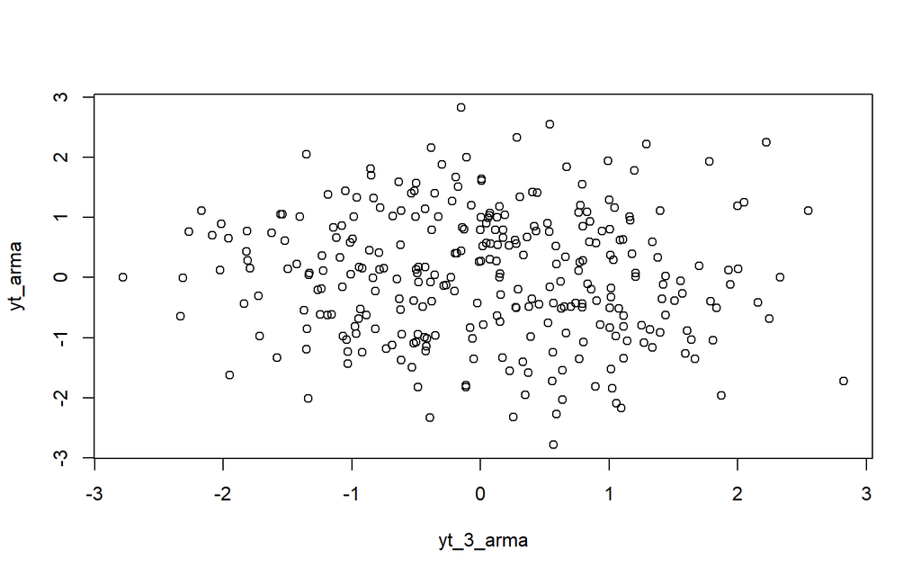

```r
plot(y=yt_arma,x=yt_3_arma)
```

Berdasarkan scatterplot tersebut, terlihat bahwa tidak ada hubungan yang jelas antara $Y_t$ dengan $Y_{t-3}$. Hal ini juga terbukti pada nilai korelasi yang rendah:

```r
cor(yt_arma,yt_3_arma)
```

```
## [1] -0.0730919
```

$$\rho_3 = \phi_1 \rho_2 + \phi_2 \rho_1
= (0.5)(0.8) + (0.2)(0.926)
= 0.5852$$